# Computer and Internet Use, from 1994 to 2015

Dalton Grady  
June 5, 2018

## Background

The topic for my project is revolved around Computer and Internet Use in the United States from 1994 to 2015.

From studying this data I hope to learn specifically how many people in the US have internet access in their homes in the current day versus previous years, and see by how much it has changed overtime.

The source of this information is from the National Telecommunications and Information Administration, and includes variables, such as if the surveyee is a householder, if their age is over 15 years old, if they use the internet at home, school or work, if the surveyee has wired high-speed internet service, works online, and then looks at various reasons as to why a household may not be online, such as being able to use internet elsewhere, not needing it at home, too expensive, and other variables.

## Data

From the data provided I am more interested in the relationship between the variables, because the amount of individuals who have internet access goes in proportion with the total amount of inviduals in various states, and country as a whole.

The variables I am focusing on are the total home internet users over the years in the whole US, as well as California and Massachusetts. Furthermore I am also looking at individuals of white and black descent and comparing total amount of inviduals who have internet access at home between the two races.

```python
#Importing the necessary librarys
import pandas as pd
import numpy as np
import matplotlib.pyplot as plt
import matplotlib.axes as ax
import statsmodels.formula.api as smf
%matplotlib inline
```

```python
#Slicing out the variable for only homeInternetUser & providing the statistics on it
df =  pd.read_csv( "ntia_computer_usage.csv" )

#Calculating the total number of households
house_holders = df[df['variable'] == 'isHouseholder']
data_house_holders = house_holders.loc[:, ['usCount']]
total_house_holders = data_house_holders.iat[12,0]

#Calculating the dataset for homeInternetUsers
home_internet_users = df[df['variable'] == 'homeInternetUser']
data_home = home_internet_users.loc[:, ['dataset','usCount', 'CACount','MACount', 'raceWhiteCount', 'raceBlackCount']]

print( data_home )
print( pd.DataFrame.describe( data_home ) )
```

```
    dataset    usCount   CACount  MACount  raceWhiteCount  raceBlackCount
17   Dec-98   57702119   7363861  1552784        49332127         2947298
33   Aug-00   94362619  11576973  2435359        77471397         6075186
53   Sep-01  116352818  13801785  2943721        93023223         8633104
75   Oct-03  129643445  15852182  3279637       101510034        10011265
119  Oct-10  190020533  22860497  4706513       135822107        18434135
149  Jul-11  187950363  22144657  4468574       134120815        18042261
174  Oct-12  205499861  24609471  4809220       140908417        20738766
217  Jul-13  195520693  23759901  4695527       133331722        19263895
278  Jul-15  206763854  24783503  4662113       137281081        21261429
            usCount       CACount       MACount  raceWhiteCount  \
count  9.000000e+00  9.000000e+00  9.000000e+00    9.000000e+00
mean   1.537574e+08  1.852809e+07  3.728161e+06    1.114223e+08
std    5.528365e+07  6.497990e+06  1.209455e+06    3.273633e+07
min    5.770212e+07  7.363861e+06  1.552784e+06    4.933213e+07
25%    1.163528e+08  1.380178e+07  2.943721e+06    9.302322e+07
50%    1.879504e+08  2.214466e+07  4.468574e+06    1.333317e+08
75%    1.955207e+08  2.375990e+07  4.695527e+06    1.358221e+08
max    2.067639e+08  2.478350e+07  4.809220e+06    1.409084e+08

       raceBlackCount
count    9.000000e+00
mean     1.393415e+07
std      6.995434e+06
min      2.947298e+06
25%      8.633104e+06
50%      1.804226e+07
75%      1.926390e+07
max      2.126143e+07
```

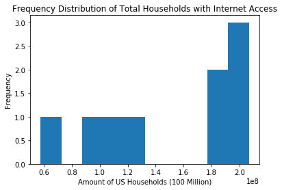

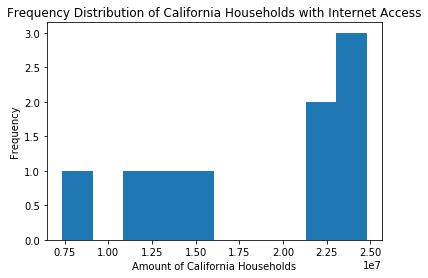

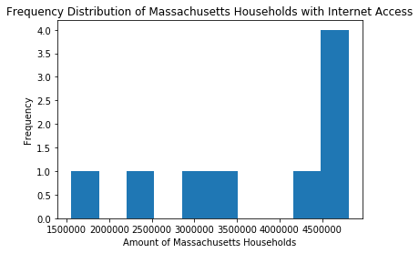

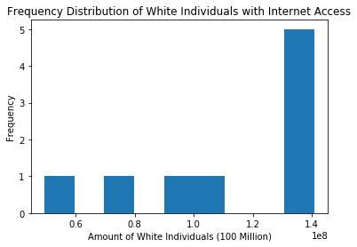

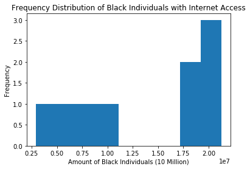

```python
#Histogram plot of total US households with Internet Access
figh_data_home = plt.figure( )
plt.hist( home_internet_users['usCount'], bins = 10 )
plt.title( "Frequency Distribution of Total Households with Internet Access")
plt.xlabel( "Amount of US Households (100 Million)" )
plt.ylabel( "Frequency" )
plt.show( )

#Histogram plot of total CA households with Internet Access
figh_data_home = plt.figure( )
plt.hist( home_internet_users['CACount'], bins = 10 )
plt.title( "Frequency Distribution of California Households with Internet Access")
plt.xlabel( "Amount of California Households" )
plt.ylabel( "Frequency" )
plt.show( )

#Histogram plot of total MA households with Internet Access
figh_data_home = plt.figure( )
plt.hist( home_internet_users['MACount'], bins = 10 )
plt.title( "Frequency Distribution of Massachusetts Households with Internet Access")
plt.xlabel( "Amount of Massachusetts Households" )
plt.ylabel( "Frequency" )
plt.show( )

#Histogram plot of total white invididuals with Internet Access
figh_data_race = plt.figure( )
plt.hist( home_internet_users['raceWhiteCount'], bins = 9 )
plt.title( "Frequency Distribution of White Individuals with Internet Access")
plt.xlabel( "Amount of White Individuals (100 Million)" )
plt.ylabel( "Frequency" )
plt.show( )

#Histogram plot of total black invididuals with Internet Access
figh_data_race = plt.figure( )
plt.hist( home_internet_users['raceBlackCount'], bins = 9 )
plt.title( "Frequency Distribution of Black Individuals with Internet Access")
plt.xlabel( "Amount of Black Individuals (10 Million)" )
plt.ylabel( "Frequency" )
plt.show( )
```

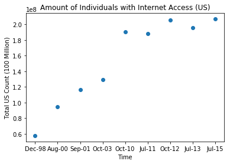

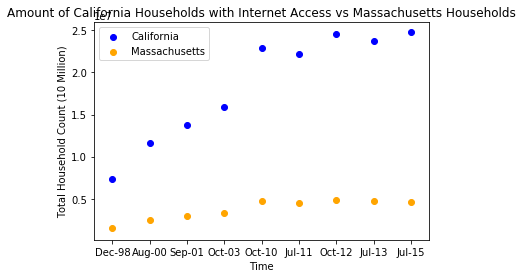

[figure not shown]

[figure not shown]

```python
#Scatterplot for total US Count
figs_data_home = plt.figure( )
plt.scatter( home_internet_users['dataset'], home_internet_users['usCount'] )
plt.title( 'Amount of Individuals with Internet Access (US)' )
plt.xlabel('Time' )
plt.ylabel( 'Total US Count (100 Million)' )
plt.show()

#Scatterplot for total MA Count
figs_data_home = plt.figure( )
plt.scatter( home_internet_users['dataset'], home_internet_users['CACount'], color = 'blue', label = "California" )
plt.scatter( home_internet_users['dataset'], home_internet_users['MACount'], color = 'orange', label = "Massachusetts" )
plt.title( 'Amount of California Households with Internet Access vs Massachusetts Households' )
plt.xlabel('Time' )
plt.ylabel( 'Total Household Count (10 Million)' )
plt.legend( )
plt.show( )

#Scatterplot for total White Count
figs_data_home = plt.figure( )
plt.scatter( home_internet_users['dataset'], home_internet_users['raceWhiteCount'] )
plt.title( 'Amount of White Individuals with Internet Access' )
plt.xlabel('Time' )
plt.ylabel( 'Total Individual Count (100 Million)' )
plt.show( )

#Scatterplot for total Black Count
figs_data_home = plt.figure( )
plt.scatter( home_internet_users['dataset'], home_internet_users['raceBlackCount'] )
plt.title( 'Amount of Black Individuals with Internet Access' )
plt.xlabel('Time' )
plt.ylabel( 'Total Individual Count (10 Million)' )
plt.show()
```